# Turbine Collision Risk: Generate Distribution Data

Cédric Scherer https://cedricscherer.com (Leibniz Institute for Zoo and Wildlife Research)https://www.izw-berlin.de/en/home.html , Christian Voigt (Leibniz Institute for Zoo and Wildlife Research)https://www.izw-berlin.de/en/home.html  
2022-09-01

## Preparation

```r
library(tidyverse)
library(here)
library(broom)
library(patchwork)

theme_set(theme_light(base_size = 13, base_family = "Open Sans"))
theme_update(
  panel.grid.major = element_line(size = .3, color = "grey93"),
  panel.grid.minor = element_blank(),
  panel.grid.major.x = element_blank(),
  strip.background = element_rect(fill = "grey60", colour = "grey60"),
  strip.text.x = element_text(hjust = 0),
  strip.text = element_text(size = 15.5),
  axis.title.x = element_text(size = 15.5, margin = margin(t = 12)),
  axis.title.y = element_text(size = 15.5, margin = margin(r = 12)),
  axis.text = element_text(size = 13.5),
  legend.title = element_text(size = 15.5, face = "bold"),
  legend.text = element_text(size = 13.5),
  plot.title = element_text(size = 24, face = "bold", margin = margin(5, 0, 5, 0)),
  plot.subtitle = element_text(margin = margin(5, 0, 25, 0), size = 19),
  plot.title.position = "plot",
  plot.margin = margin(rep(12, 4))
)

## source functions to generate and visualize distributions
source(here("R", "src", "generate-distributions.R"))
```

## Research Question

- Predictive power of the acoustic monitoring

> Is the predictive power of the current acoustic monitoring sufficient enough to estimate the true number of killed bats?

### Predictions

The predictive power of the acoustic monitoring for the extrapolation of the expected number of stroke victims is decreasing

- in case the crossing bats are not distributed uniformly or randomly.
- with increasing length of the rotor blades.
- for species with high-frequency echo calls.

### Open Questions

- wie die Dichte skalieren zwischen großen und kleinen Windrädern?
  - z.B. von innen nach außen abhängig von relativer oder absoluter Distanz zum Mittelpunkt?
- globale oder lokale Anzahl an Fledermäusen konstant halten?

We have the following parameters we can vary:

- length of rotor blades (`radius_rotor`) - 60 m versus 33 m
  - determines area of wind turbine (`area_rotor` as `pi * radius_rotor^2`)
- proportion of area covered by acoustic monitoring (`proportion_covered`)
  - determines area of acoustic monitoring (`area_monitored` as `area_rotor * proportion_covered`)
  - determines radius to detect bars (`radius_monitored` as `sqrt(area_monitored / pi)`)
- number of bats simulated (`n`)
  - could be either total (for now) or number monitored (maybe later)

## Simulated Data

```r
scenarios <-
  read_rds(here("output", "data-proc", "simulation-runs-norm.rds")) %>%
  ## remove extremely skewed distributions
  filter(!str_detect(distribution, "_5$")) %>%
  ## remove outdated 23% scenario
  filter(prop_monitored != .23) %>%
  group_by(n, prop_monitored, distribution) %>%
  mutate(diff = prop_monitored - median(prop_n_monitored)) %>%
  ungroup() %>%
  mutate(
    distribution = factor(
      distribution,
      levels = c(
        "uniform", "random",
        "inner_1", "inner_3",
        "outer_1", "outer_3",
        "bottom_1", "bottom_3",
        "top_1", "top_3"
      ),
      labels = c(
        "a) uniform", "b) random",
        "c) inner — weak", "d) inner — strong",
        "e) outer — weak", "f) outer — strong",
        "g) bottom — weak", "h) bottom — strong",
        "i) top — weak", "j) top — strong"
      )
    ),
    prop_monitored_lab = paste0(prop_monitored * 100, "%"),
    prop_monitored_lab = fct_reorder(prop_monitored_lab, prop_monitored)
  )
```

## Visualizations Bat Passes

### Error Bars Deviation Bat Passes Recorded vs. Expected

Distribution (col) x Monitored Area (color) x Passes (x)

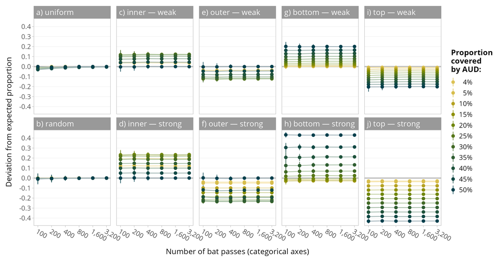

```r
scenarios %>%
  group_by(distribution, prop_monitored, n) %>%
  summarize(mean = mean(prop_n_monitored), sd = sd(prop_n_monitored)) %>%
  ungroup() %>%
  mutate(
    base = mean - prop_monitored,
    min = base - sd,
    max = base + sd,
    n_cat = factor(scales::comma(n), levels = as.character(scales::comma(unique(n))))
  ) %>%
  ggplot(aes(n_cat, base, color = prop_monitored, group = prop_monitored)) +
  geom_hline(aes(yintercept = 0), color = "grey75", size = 1.2)  +
  geom_line(
    aes(color = prop_monitored,
        color = after_scale(colorspace::desaturate(colorspace::lighten(color, .6), .4))),
    size = .7, show.legend = FALSE
  ) +
  geom_pointrange(aes(ymin = min, ymax = max), size = .5) +
  facet_wrap(~distribution, nrow = 2, dir = "v") +
  # scale_x_discrete(expand = c(.05, .05), guide = guide_axis(n.dodge = 2)) + ## dodged
  scale_x_discrete(expand = c(.05, .05)) + ## rotated
  scale_y_continuous(expand = c(.012, .012), breaks = -5:5 / 10) +
  scico::scale_color_scico(
    palette = "bamako", end = .85, direction = -1, name = "Proportion\ncovered\nby AUD:",
    breaks = c(.04, seq(.05, .5, by = .05)), labels = scales::percent_format(accuracy = 1)
  ) +
  guides(color = guide_legend(keywidth = unit(.6, "lines"), keyheight = unit(1.5, "lines"))) +
  labs(x = "Number of bat passes (categorical axes)", y = "Deviation from expected proportion") +
  theme(panel.spacing.x = unit(.8, "lines"),
        axis.text.x = element_text(angle = -30, vjust = 1, hjust = 0), ## rotated
        legend.text = element_text(hjust = 1))
```

```r
ggsave(here("plots", "fig3_passes_recorded_mean_sd_lines_cat_rotated.png"), width = 14, height = 7.3, dpi = 800)
```

### Boxplots Relative Difference Predicted vs. Expected

#### Dedicated Scenarios

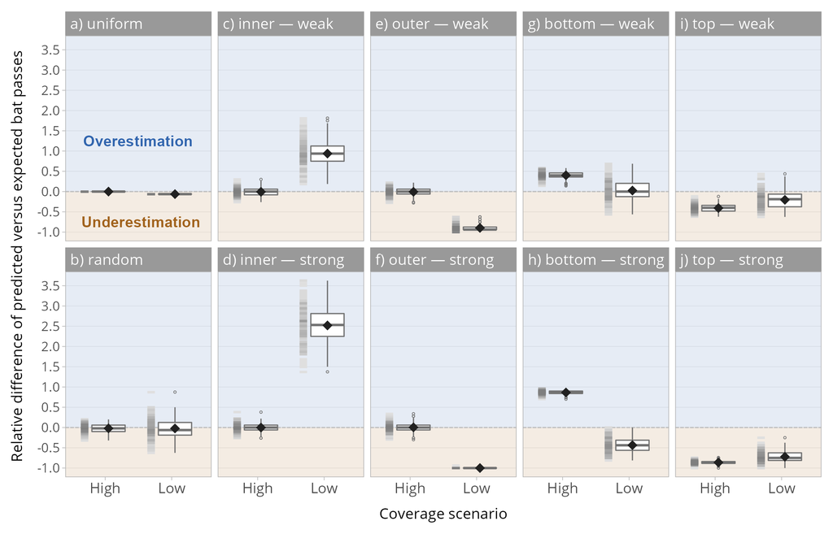

```r
colors <- scico::scico(n = 9, palette = "roma")[c(8,2)]

data_rel_scen <-
  scenarios %>%
  filter((n == 400 & prop_monitored == .04) | (n == 100 & prop_monitored == .5)) %>%
  mutate(
    diff_passes = ((n_monitored / prop_monitored) - n) / n,
    scenario = if_else(prop_monitored == .04, "Low", "High")
  ) %>%
  bind_rows(
    tibble(
      distribution = factor("a) uniform", levels = levels(scenarios$distribution)),
      label = c("Overestimation", "Underestimation"),
      scenario = "High",
      diff_passes = c(1.25, -.75),
      color = colors
    )
  )

data_rel_scen %>%
  filter(is.na(label)) %>%
  ggplot(aes(scenario, diff_passes)) +
  annotate(geom = "rect", xmin = -Inf, xmax = Inf, ymin = 0, ymax = Inf, fill = colors[1], alpha = .12) +
  annotate(geom = "rect", xmin = -Inf, xmax = Inf, ymin = -Inf, ymax = 0, fill = colors[2], alpha = .12) +
  geom_text(data = data_rel_scen, aes(label = label, color = color), hjust = .2, fontface = "bold", size = 5.5) +
  geom_hline(yintercept = 0, size = .6, linetype = "31", color = "grey75") +
  geom_boxplot(color = "grey45", size = .6, width = .5,
               position = position_nudge(x = .05),
               outlier.size = .9, outlier.shape = 1) +
  geom_point(color = "grey90", shape = "-", size = 10,
             position = position_nudge(x = -.31)) +
  geom_point(color = "grey45", shape = "-", size = 10, alpha = .05,
             position = position_nudge(x = -.31)) +
  stat_summary(geom = "point", shape = 18, size = 4.5, color = "#212121",
               position = position_nudge(x = .05)) +
  facet_wrap(~distribution, nrow = 2, dir = "v") +
  scale_y_continuous(expand = c(.04, .04), breaks = seq(-1, 3.5, by = .5)) +
  scale_color_identity() +
  labs(x = "Coverage scenario",
       y = "Relative difference of predicted versus expected bat passes") +
  theme(axis.text.x = element_text(size = 15))
```

```r
ggsave(here("plots", "fig4_passes_difference_boxplots_rel_scenarios.png"), width = 12, height = 7.7, dpi = 800)
```

#### All Scenarios with 400 Bat Passes

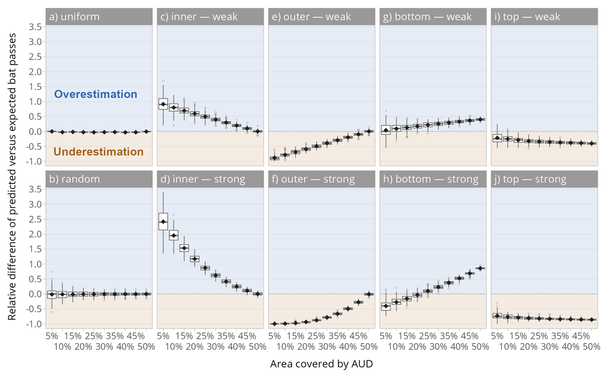

```r
data_rel <-
  scenarios %>%
  filter(n == 400) %>%
  filter(!prop_monitored == .04) %>% ## remove dedicated scenario
  mutate(diff_passes = ((n_monitored / prop_monitored) - n) / n) %>%
  bind_rows(
    tibble(
      distribution = factor("a) uniform", levels = levels(scenarios$distribution)),
      label = c("Overestimation", "Underestimation"),
      prop_monitored_lab = factor("10%", levels = levels(scenarios$prop_monitored_lab)),
      diff_passes = c(1.25, -.67),
      color = colors
    )
  )

data_rel %>%
  filter(is.na(label)) %>%
  ggplot(aes(prop_monitored_lab, diff_passes)) +
  annotate(geom = "rect", xmin = -Inf, xmax = Inf, ymin = 0, ymax = Inf, fill = colors[1], alpha = .12) +
  annotate(geom = "rect", xmin = -Inf, xmax = Inf, ymin = -Inf, ymax = 0, fill = colors[2], alpha = .12) +
  geom_text(data = data_rel, aes(label = label, color = color), hjust = .1, fontface = "bold", size = 6) +
  geom_hline(yintercept = 0, size = .6, linetype = "31", color = "grey75") +
  geom_boxplot(color = "grey45", width = .85, size = .5,
               outlier.size = .8, outlier.alpha = .4, outlier.shape = 1) +
  stat_summary(geom = "point", shape = 18, size = 3, color = "#212121") +
  facet_wrap(~distribution, nrow = 2, dir = "v") +
  scale_x_discrete(guide = guide_axis(n.dodge = 2)) +
  scale_y_continuous(expand = c(.03, .03), breaks = seq(-1, 3.5, by = .5)) +
  scale_color_identity() +
  labs(x = "Area covered by AUD",
       y = "Relative difference of predicted versus expected bat passes")
```

```r
ggsave(here("plots", "figS3_passes_difference_boxplots_rel.png"), width = 12.5, height = 7.8, dpi = 800)
```

## Visualizations Fatalities

```r
fits_scenarios <-
  scenarios %>%
  mutate(n_expected = ifelse(n_monitored == 0, 0, n_monitored / prop_monitored)) %>%
  nest(data = -c(distribution, prop_monitored, prop_monitored_lab)) %>%
  mutate(
    fit = map(data, ~ lm(n_fatalities ~ n_expected , data = .x)),
    tidied = map(fit, tidy),
    glance = map(fit, glance),
    augment = map(fit, augment),
    rsq = glance %>% map_dbl('r.squared'),
    slope = tidied %>% map_dbl(function(x) x$estimate[2]),
    se = tidied %>% map_dbl(function(x) x$std.error[2])
  ) %>%
  dplyr::select(distribution, prop_monitored, prop_monitored_lab, rsq, slope, se) %>%
  mutate(
    t = (.01 - slope) / se, ## t value = (expected slope - observed slope) / standard error
    p = 2*pt(abs(t), 1200-2, lower.tail = FALSE) ## p-value = two-tailed test of t value and d.f. (n - 2)
  )
```

### Regression Fatalities vs Predicted Bat Passes — What we observe

#### Dedicated Scenarios

##### Low-Coverage Scenario

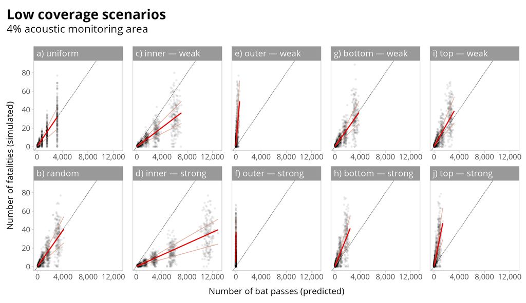

```r
p_data_low <-
  scenarios %>%
  filter(prop_monitored == .04) %>%
  mutate(n_expected = ifelse(n_monitored == 0, 0, n_monitored / prop_monitored))

p_data_low %>%
  left_join(fits_scenarios) %>%
  ggplot(aes(n_expected, n_fatalities)) +
  geom_abline(intercept = 0, slope = .01, color = "grey45", linetype = "31", size = .4) +
  geom_point(shape = 16, alpha = .08) +
  geom_quantile(quantiles = c(0.25, 0.75), color = "#D89684", alpha = .7, size = .6) +
  geom_quantile(quantiles = c(0.5), color = "#E60000", size = .9) +
  # geom_text(
  #   aes(label = paste("R² = ", sprintf("%1.2f", rsq)),
  #       x = 0, y = 87),
  #   stat = "unique", family = "Open Sans", color = "grey30",
  #   size = 3.7, hjust = 0
  # ) +
  facet_wrap(~ distribution, nrow = 2, scales = "free_x", dir = "v") +
  scale_x_continuous(breaks = 0:5*4000, limits = c(NA, max(p_data_low$n_expected)),
                     labels = scales::comma_format()) +
  scale_y_continuous(breaks = 0:4*20) +
  labs(title = "Low coverage scenarios",
       subtitle = "4% acoustic monitoring area",
       x = "Number of bat passes (predicted)", y = "Number of fatalities (simulated)") +
  theme(
    panel.grid.major.y = element_blank(),
    panel.spacing.x = unit(1.2, "lines"),
    panel.spacing.y = unit(.6, "lines"),
    legend.text = element_text(hjust = 1),
    strip.text = element_text(hjust = 0),
    plot.subtitle = element_text(margin = margin(t = 0, b = 20))
  )
```

```r
ggsave(here("plots", "fig5_fatalities_correlation_low_coverage.png"), width = 13, height = 7.5, dpi = 800)
```

#### High-Coverage Scenario

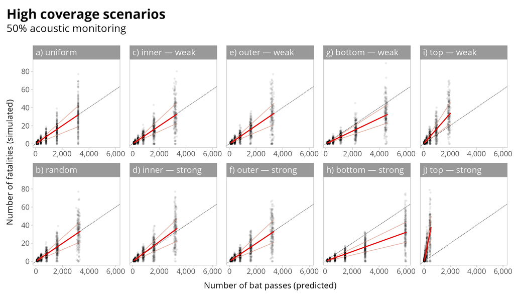

```r
p_data_high <-
  scenarios %>%
  filter(prop_monitored == .5) %>%
  mutate(n_expected = ifelse(n_monitored == 0, 0, n_monitored / prop_monitored))

p_data_high %>%
  left_join(fits_scenarios) %>%
  ggplot(aes(n_expected, n_fatalities)) +
  geom_abline(intercept = 0, slope = .01, color = "grey45", linetype = "31", size = .4) +
  geom_point(shape = 16, alpha = .08) +
  geom_quantile(quantiles = c(0.25, 0.75), color = "#D89684", alpha = .7, size = .6) +
  geom_quantile(quantiles = c(0.5), color = "#E60000", size = .9) +
  # geom_text(
  #   aes(label = paste("R² = ", sprintf("%1.2f", rsq)),
  #       x = 0, y = 87),
  #   stat = "unique", family = "Open Sans", color = "grey30",
  #   size = 3.7, hjust = 0
  # ) +
  facet_wrap(~ distribution, nrow = 2, scales = "free_x", dir = "v") +
  scale_x_continuous(breaks = 0:5*2000, limits = c(NA, max(p_data_high$n_expected)),
                     labels = scales::comma_format()) +
  scale_y_continuous(breaks = 0:4*20) +
  labs(title = "High coverage scenarios",
       subtitle = "50% acoustic monitoring",
       x = "Number of bat passes (predicted)", y = "Number of fatalities (simulated)") +
  theme(
    panel.grid.major.y = element_blank(),
    panel.spacing.x = unit(1.2, "lines"),
    panel.spacing.y = unit(.6, "lines"),
    legend.text = element_text(hjust = 1),
    strip.text = element_text(hjust = 0),
    plot.subtitle = element_text(margin = margin(t = 0, b = 20))
  )
```

```r
ggsave(here("plots", "fig6_fatalities_correlation_high_coverage.png"), width = 13, height = 7.5, dpi = 800)
```

```r
p_data_all <- scenarios %>%
  mutate(n_expected = ifelse(n_monitored == 0, 0, n_monitored / prop_monitored))

p_data_all %>%
  ggplot(aes(n_expected, n_fatalities)) +
  geom_abline(intercept = 0, slope = .01, color = "grey45", linetype = "31", size = .4) +
  geom_point(shape = 16, alpha = .08) +
  geom_quantile(quantiles = c(0.25, 0.75), color = "#D89684", alpha = .7, size = .6) +
  geom_quantile(quantiles = c(0.5), color = "#E60000", size = .9) +
  # geom_text(
  #   aes(label = paste("R² = ", sprintf("%1.2f", rsq)),
  #       x = 0, y = 87),
  #   stat = "unique", family = "Open Sans", color = "grey30",
  #   size = 3.7, hjust = 0
  # ) +
  facet_grid(prop_monitored_lab ~ distribution, scales = "free_x") +
  scale_x_continuous(breaks = 0:5*4000, limits = c(NA, max(p_data_all$n_expected)),
                     labels = scales::comma_format()) +
  scale_y_continuous(breaks = 0:4*20) +
  labs(x = "Number of bat passes (predicted)", y = "Number of fatalities (simulated)") +
  theme(
    panel.grid.major.y = element_blank(),
    panel.spacing = unit(.8, "lines"),
    legend.text = element_text(hjust = 1),
    strip.text.x = element_text(hjust = 0),
    strip.text.y = element_text(angle = 0, hjust = 1, margin = margin(3, 9, 3, 9))
  ) -> d

ggsave(here("plots", "figS4_fatalities_correlation_all.png"), width = 24, height = 15, dpi = 800)
```

### p-Values Slopes

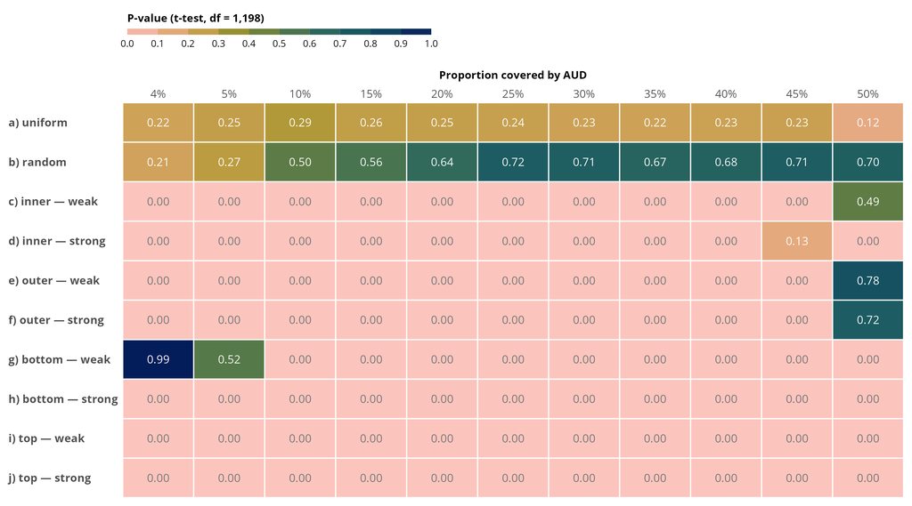

```r
fits_scenarios %>%
  ggplot(aes(prop_monitored_lab, fct_rev(distribution))) +
  geom_tile(aes(fill = p), color = "white", size = .8) +
  geom_text(
    aes(label = sprintf("%1.2f", p), color = p < .05),
    family = "Open Sans", size = 5.7
  ) +
  coord_cartesian(expand = FALSE, clip = "off") +
  scale_x_discrete(position = "top") +
  scale_color_manual(values = c("white", "#737373"), guide = "none") +
  scico::scale_fill_scico(
    palette = "batlowW", direction = -1, end = .85,
    name = "P-value (t-test, df = 1,198)", limits = c(0, 1),
    breaks = seq(0, 1, by = .1), labels = function(x) sprintf("%1.1f", x)
  ) +
  scale_alpha_manual(values = c(0, 1), guide = "none") +
  guides(fill = guide_colorsteps(title.position = "top", show.limits = TRUE)) +
  labs(x = "Proportion covered by AUD", y = NULL) +
  theme(panel.spacing = unit(.9, "lines"),
        panel.background = element_rect(size = .7, color = "white", fill = "transparent"),
        panel.border = element_rect(color = "transparent", fill = "transparent"),
        axis.title.x.top = element_text(face = "bold", margin = margin(t = 8, b = 12)),
        axis.text.x = element_text(size = 16),
        axis.text.y = element_text(size = 16, face = "bold", hjust = 0),
        axis.ticks = element_line(color = "transparent"),
        axis.ticks.length = unit(.3, "lines"),
        legend.position = "top",
        legend.justification = "left",
        legend.key.width = unit(6, "lines"), legend.key.height = unit(.6, "lines"))
```

```r
ggsave(here("plots", "tab1_slopes_ttest_heatmap.png"), width = 12, height = 6.7, dpi = 800)
```

**Session Info**

```r
Sys.time()
```

```
[1] "2022-09-01 19:29:50 CEST"
```